# CanonCor

Волканова Маргарита

16 октября 2018 г

## Канонические корреляции.

Построить канонические корреляции для двух групп признаков: индексы тяжести с 7 по 13 (описание там же в инструкциях…) и с 20 по 24, характеризующие физическое и психологическое состояние. intpla 1 (место лечения - 1 - амбулаторно) Это принцип на выявление зависимости между двумя наборасми признаов ($G_1$ и $G_2$).Задача: найти такие линейные комбинации чтобы корреляция между ними была максимальна.

```r
library(CCA)
DataN <- read.csv("D:/Dokumy/Desktop/Alexeeva/DataNark.csv", header = TRUE, sep = ";",dec = ",")
DataN <- DataN[DataN$intpla == 1,c(7:13,20:24)]
DataN<-na.omit(DataN)
DataN[1:10,]
```

```
##    asi1_med asi2_emp asi3_alc asi4_dr asi5_leg asi6_soc asi7_psy cravin
## 1      0.19      0.7     0.12     0.3     0.06      0.5      0.2    4.6
## 3      0.50      1.0     0.30     0.3     0.07      0.6      0.2    9.5
## 4      0.00      0.8     0.05     0.3     0.00      0.4      0.2    2.7
## 6      0.52      0.5     0.10     0.3     0.07      0.6      0.5   10.0
## 7      0.00      1.0     0.09     0.4     0.15      1.0      0.3    7.8
## 8      0.00      0.2     0.04     0.3     0.14      0.7      0.3    3.8
## 9      0.00      1.0     0.01     0.3     0.24      0.6      0.2    3.1
## 11     0.00      1.0     0.00     0.3     0.19      0.6      0.5    4.8
## 12     0.70      0.2     0.10     0.3     0.06      0.3      0.3    5.6
## 14     0.60      1.0     0.15     0.3     0.05      0.4      0.4    4.6
##    rabdru rubsex gaf bdi
## 1       1      4  55  25
## 3       6      1  45  29
## 4      11      4  40  28
## 6       3      2  41  33
## 7       9      7  40  23
## 8       1      7  45  24
## 9      13      3  40  24
## 11     12      7  45  31
## 12      6      5  45  24
## 14      4      5  45  23
```

```r
X <- DataN[,c(1:7)]
Y <- DataN[,c(8:12)]
#t<-c(c(7:13),c(20:24))
#cov(DataN[,t])
X[1,]
```

```
##   asi1_med asi2_emp asi3_alc asi4_dr asi5_leg asi6_soc asi7_psy
## 1     0.19      0.7     0.12     0.3     0.06      0.5      0.2
```

```r
n<-nrow(X)
```

Все компоненты надо центрировать ($EX_i=0$), нормировать

```r
t<-c(c(7:13),c(20:24))
if (ncol(X) > ncol(Y))
  {
  Z <- X;
  X <- Y;
  Y <- Z
  }
r <- ncol(X)
s <- ncol(Y)
U <- apply(cbind(X,Y),2,function(x)(x-mean(x))/sd(x))
n <- nrow(U)
S <- cov(U)
U1 <- DataN[,c(1:7)]
U2 <- DataN[,c(8:12)]
#обмен столбцов?
U <- apply(cbind(U1,U2),2,function(x)(x-mean(x))/sd(x))
```

Ковариационная матрица подвекторов:

```r
Sigma<-cov(U)
sigm11<-Sigma[1:7,1:7]
sigm12<-Sigma[1:7,8:12]
sigm21<-Sigma[8:12,1:7]
sigm22<-Sigma[8:12,8:12]
```

Далее считаем:$\sigma_{11}=EU_1U_1^T$,$\sigma_{22}=EU_2U_2^T$,$\sigma_{21}=\sigma_{21}=EU_2U_1^T$ - ковариационные матрицы подвекторов образующие общую ковариационную матрицу.

```r
sigm11
```

```
##             asi1_med    asi2_emp     asi3_alc    asi4_dr    asi5_leg
## asi1_med  1.00000000 -0.07302813  0.382852224 0.08839358 -0.33706286
## asi2_emp -0.07302813  1.00000000  0.149379724 0.22454005  0.14943471
## asi3_alc  0.38285222  0.14937972  1.000000000 0.20209107 -0.19529373
## asi4_dr   0.08839358  0.22454005  0.202091071 1.00000000  0.04347453
## asi5_leg -0.33706286  0.14943471 -0.195293731 0.04347453  1.00000000
## asi6_soc -0.19995265  0.09516136 -0.009915286 0.19883259  0.17467442
## asi7_psy  0.02723809  0.26988823  0.078405248 0.07388669  0.16504399
##              asi6_soc   asi7_psy
## asi1_med -0.199952647 0.02723809
## asi2_emp  0.095161362 0.26988823
## asi3_alc -0.009915286 0.07840525
## asi4_dr   0.198832591 0.07388669
## asi5_leg  0.174674421 0.16504399
## asi6_soc  1.000000000 0.06340184
## asi7_psy  0.063401836 1.00000000
```

Для проверки используем пакет CCA.

```r
matcor(U1,U2)$Xcor
```

```
##             asi1_med    asi2_emp     asi3_alc    asi4_dr    asi5_leg
## asi1_med  1.00000000 -0.07302813  0.382852224 0.08839358 -0.33706286
## asi2_emp -0.07302813  1.00000000  0.149379724 0.22454005  0.14943471
## asi3_alc  0.38285222  0.14937972  1.000000000 0.20209107 -0.19529373
## asi4_dr   0.08839358  0.22454005  0.202091071 1.00000000  0.04347453
## asi5_leg -0.33706286  0.14943471 -0.195293731 0.04347453  1.00000000
## asi6_soc -0.19995265  0.09516136 -0.009915286 0.19883259  0.17467442
## asi7_psy  0.02723809  0.26988823  0.078405248 0.07388669  0.16504399
##              asi6_soc   asi7_psy
## asi1_med -0.199952647 0.02723809
## asi2_emp  0.095161362 0.26988823
## asi3_alc -0.009915286 0.07840525
## asi4_dr   0.198832591 0.07388669
## asi5_leg  0.174674421 0.16504399
## asi6_soc  1.000000000 0.06340184
## asi7_psy  0.063401836 1.00000000
```

```r
#correl <- matcor(U1, U2)
#img.matcor(correl, type = 2)
```

Канонические случайные величины обозначим через $V_1=L^TU_1$, $V_2=M^TU_2$, где $L=(l_1,\ldots,l_r)^T$ и $M=(m_1,\ldots,m_s)^T$-вектора канонических коэффициентов.$cov(V_1,V_2)=M^T\Sigma L =>\max$ при $DV_1=DV_2=1$.\ M - собственный вектор уравнения:\
$$|\Sigma_{21}\Sigma_{11}^{-1}\Sigma_{12}-\delta^2\Sigma_{22}|=0$$
Аналогично, L - собственный вектор уравнения:\
$$|\Sigma_{21}\Sigma_{22}^{-1}\Sigma_{12}-\delta^2\Sigma_{11}|=0$$
($\delta^2$ - собственные корни)
$$A=\Sigma^{-1}_{11}\Sigma_{12}\Sigma^{-1}_{22}\Sigma_{21}$$
Собственные значения этой матрицы, ранжированные по убыванию, равняются квадратам коэффициентов канонических корреляций. Для разрешимости задачи необходимо, чтобы корреляционные матрицы $\Sigma_{11}$ и $\Sigma_{22}$ были положительно определены. Это означает, что в составе X1 и X2 не должны существовать линейно зависимые компоненты. В противном случае следует один или несколько показателей-факторов исключить. Вычисление:

```r
A <- solve(sigm11)%*%sigm12%*%solve(sigm22)%*%sigm21
A_ei <- eigen(A)
#векторы канонических коэффициентов - M - матрица собственных векторов
M <- A_ei$vectors
M
```

```
##             [,1]       [,2]       [,3]       [,4]       [,5]       [,6]
## [1,] -0.74321851 -0.2253446 -0.4303160  0.3470791  0.1953513  0.3784488
## [2,] -0.23474951 -0.5813505  0.5226922  0.2839091  0.2156127 -0.3584382
## [3,] -0.17441293 -0.1761790  0.2633704  0.1231185 -0.4782383  0.1307925
## [4,]  0.02600184  0.1267744  0.2865710 -0.4845911  0.5144983  0.4951044
## [5,]  0.55251218 -0.5791388 -0.1275013  0.2431481 -0.2743400  0.6023549
## [6,]  0.07519051 -0.2191237 -0.4687313  0.3078466  0.5538183 -0.2376785
## [7,] -0.22472120 -0.4251160 -0.3926429 -0.6285336 -0.1998787 -0.2161967
##             [,7]
## [1,] -0.25790972
## [2,] -0.44574415
## [3,]  0.77414164
## [4,]  0.22914631
## [5,]  0.10324907
## [6,]  0.26622211
## [7,] -0.03816861
```

```r
#канонические корреляциив в квадрате - Собственные числа
A_ro <- A_ei$values
A_ro
```

```
## [1]  2.419234e-01  1.384998e-01  7.685972e-02  2.408398e-02  7.653343e-03
## [6] -9.267636e-18  7.485046e-19
```

```r
R_11<-solve(sigm11)
```

```r
B <- solve(sigm22)%*%sigm21%*%solve(sigm11)%*%sigm12
B
```

```
##              cravin       rabdru       rubsex          gaf          bdi
## cravin  0.157493950 -0.046462200 -0.003861303  0.061723739  0.034818312
## rabdru -0.027467688  0.061112718  0.017288646 -0.058397957 -0.004668414
## rubsex -0.007846837  0.006106867  0.025024707  0.009056365 -0.042141314
## gaf     0.069079831 -0.070372745 -0.007883570  0.105947478  0.011128249
## bdi     0.038070207 -0.011458654 -0.025434152  0.004086437  0.139441352
```

```r
B_ei <- eigen(B)
#векторы канонических коэффициентов - Собственные вектора
L <- B_ei$vectors
L
```

```
##             [,1]       [,2]       [,3]       [,4]        [,5]
## [1,]  0.70425187 -0.1503924 -0.7164707 -0.1240625 -0.04432659
## [2,] -0.29875280  0.1750730 -0.4769342  0.4486409 -0.65326549
## [3,] -0.07638258 -0.3246050 -0.1030145  0.6779410  0.63743198
## [4,]  0.54429766 -0.3259047  0.4127424  0.5262348 -0.39575852
## [5,]  0.33568113  0.8574085  0.2797056  0.2163393  0.09129634
```

```r
#канонические корреляциив в квадрате - Собственные числа
B_ro <- B_ei$values
B_ro
```

```
## [1] 0.241923381 0.138499784 0.076859720 0.024083977 0.007653343
```

```r
sqrt(B_ro)
```

```
## [1] 0.49185707 0.37215559 0.27723586 0.15519013 0.08748339
```

```r
cancor(X,Y)$cor
```

```
## [1] 0.49185707 0.37215559 0.27723586 0.15519013 0.08748339
```

```r
#U_1<-solve(sigm11)%*%sigm12%*%L[,1]/B_ro[1]
#U_1#X_i
#L[,1]# - соответствующий характерестический вектор Yj

CC<-cc(X,Y)

u_1<-CC$scores$corr.X.xscores
u_1
```

```
##              [,1]        [,2]        [,3]       [,4]        [,5]
## cravin -0.7212173 -0.02439138  0.67530604 -0.1274120 -0.08353826
## rabdru  0.4091920  0.23150613  0.48508471  0.5335781  0.50887525
## rubsex  0.1063844 -0.12949621  0.23434144  0.7328969 -0.61632735
## gaf    -0.5069276 -0.38968240 -0.51951808  0.3810928  0.41957270
## bdi    -0.3624659  0.85960371 -0.08934982  0.2910224 -0.19241244
```

```r
v_1<-CC$scores$corr.Y.yscores
v_1
```

```
##                 [,1]       [,2]       [,3]        [,4]        [,5]
## asi1_med -0.84667481 0.01052781 -0.2474410 -0.21175911 -0.01996611
## asi2_emp -0.14560558 0.70666466  0.5584126 -0.07988768 -0.22196920
## asi3_alc -0.52181051 0.21764344  0.2669548 -0.12537334  0.25654996
## asi4_dr  -0.08932656 0.14355448  0.3332903  0.42340459 -0.61934033
## asi5_leg  0.66107601 0.59295231 -0.1029531 -0.09156107  0.14032097
## asi6_soc  0.24657017 0.29760964 -0.3726107 -0.21237753 -0.63547432
## asi7_psy -0.19014786 0.63211658 -0.3114001  0.63392121  0.15950490
```

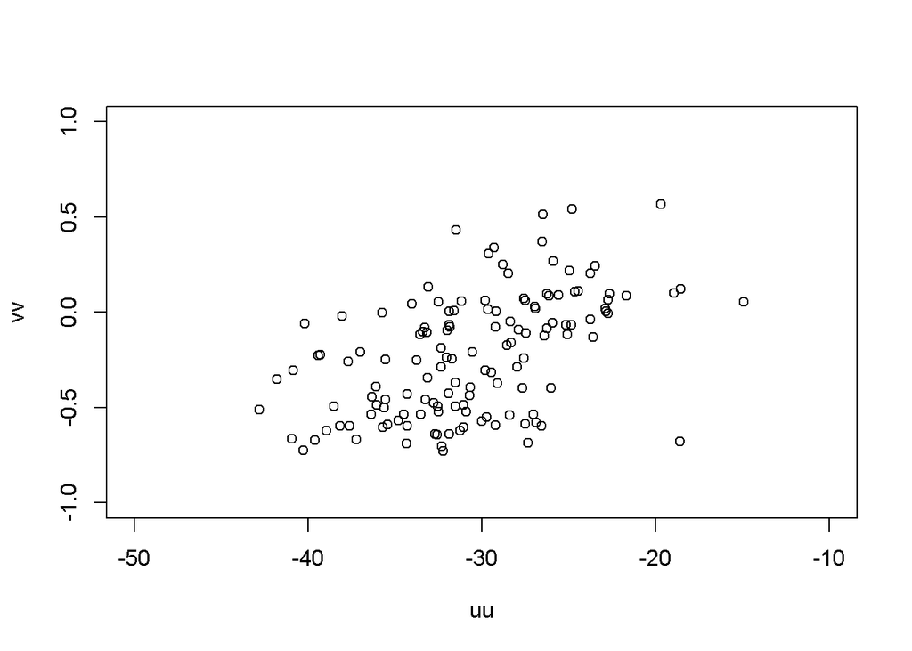

```r
#plot( sum(X[1,]*U_1), sum(Y[1,]*L[,1]))
uu<-rep(0,n)
vv<-rep(0,n)
for (i in 1:n){
  for (j in 1:n){
   uu[i]<-sum(X[i,]*u_1)
   vv[j]<-sum(Y[j,]*v_1)
  }
}
plot(uu,vv,xlim=c(-50,-10),ylim=c(-1,1))
```

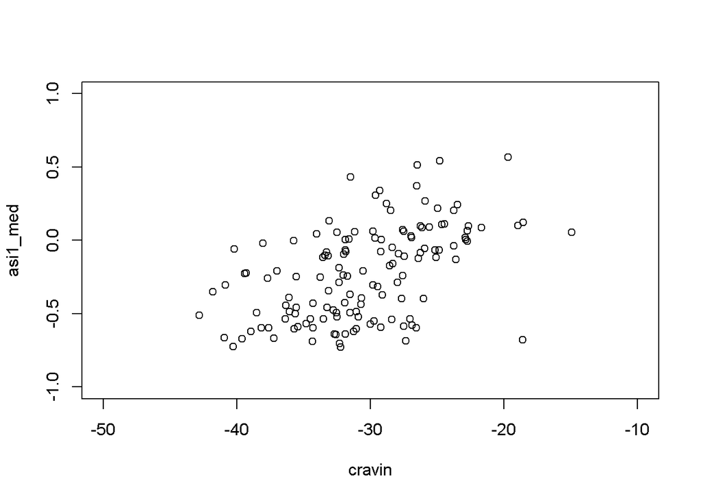

```r
cravin<-rep(0,n)
asi1_med<-rep(0,n)
for (i in 1:n){
  for (j in 1:n){
   cravin[i]<-sum(X[i,]*u_1[,1])
asi1_med[j]<-sum(Y[j,]*v_1[,1])
  }
}
plot(cravin,asi1_med,xlim=c(-50,-10),ylim=c(-1,1))
```

```r
t = -(n - 1 -(r+s+1)/2)*log(prod(1-A_ro))
t
```

```
## [1] 69.68219
```

```r
p_value <- 1 - pchisq(t,(r*s))
p_value
```

```
## [1] 0.0004380665
```

```r
#для второй корреляции
stat = -(n - 2 - (r+s+1)/2)*log(prod(1-A_ro[2:5]))
stat
```

```
## [1] 33.55335
```

```r
p_val <- 1 - pchisq(stat,((r-1)*(s-1)))
p_val#>0,05 => одна значимая
```

```
## [1] 0.09292567
```

```r
u_1[,1]
```

```
##     cravin     rabdru     rubsex        gaf        bdi
## -0.7212173  0.4091920  0.1063844 -0.5069276 -0.3624659
```

```r
v_1[,1]
```

```
##    asi1_med    asi2_emp    asi3_alc     asi4_dr    asi5_leg    asi6_soc
## -0.84667481 -0.14560558 -0.52181051 -0.08932656  0.66107601  0.24657017
##    asi7_psy
## -0.19014786
```